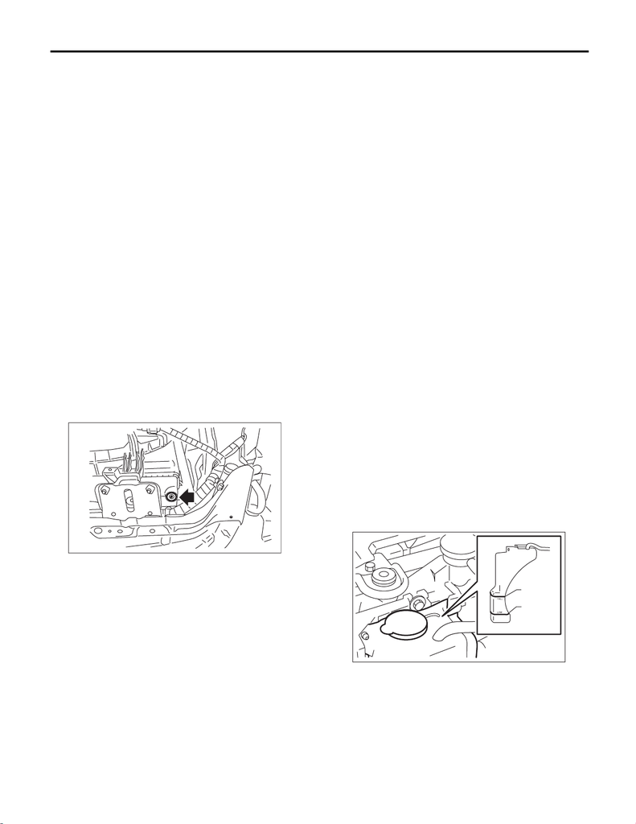

CO(STI)-13

Engine Coolant

COOLING

3. Engine Coolant

A: INSPECTION

NOTE:

When adding the engine coolant, always use SUB-

ARU Super Coolant.

1) Park the vehicle on a level surface.

2) Check the engine coolant amount, and if the

coolant level is low, check for the coolant leakage,

and then add the engine coolant.

(1) Make sure the engine coolant level in the

reservoir tank is between “FULL” and “LOW”

with the engine in a cold condition.

(2) Open the cap of coolant filler tank, and

check that the engine coolant is filled up to the

filler neck position.

B: REPLACEMENT

1. DRAINING OF ENGINE COOLANT

1) Lift up the vehicle.

2) Remove the under cover. <Ref. to EI-21, RE-

MOVAL, Front Under Cover.>

3) Remove the drain plug to drain engine coolant

into container.

NOTE:

Remove the coolant filler tank cap so that engine

coolant will drain faster.

4) Install the drain plug.

NOTE:

Use new O-rings.

5) Install the under cover. <Ref. to EI-22, INSTAL-

LATION, Front Under Cover.>

2. FILLING OF ENGINE COOLANT

1) Pour cooling system conditioner through the fill-

er neck of coolant filler tank.

Cooling system protective agent:

Refer to “SPECIFICATION” for cooling sys-

tem protective agent. <Ref. to CO(STI)-2,

SPECIFICATION, General Description.>

2) Fill the engine coolant into coolant filler tank up

to the filler neck position.

Recommended engine coolant:

Refer to “SPECIFICATION” for recommended

engine coolant. <Ref. to CO(STI)-2, SPECIFI-

CATION, General Description.>

Engine coolant level:

Refer to “SPECIFICATION” for engine cool-

ant level. <Ref. to CO(STI)-2, SPECIFICA-

TION, General Description.>

Engine coolant concentration:

Refer to “ADJUSTMENT” for the recommend-

ed engine coolant concentration. <Ref. to

CO(STI)-14, ADJUSTMENT, Engine Coolant.>

CAUTION:

Do not confuse the cap of coolant filler tank and

cap of radiator.

NOTE:

• When pouring the engine coolant, the radiator

side cap must not be removed.

• The SUBARU Super Coolant contains anti-

freeze and anti-rust agents, and is especially made

for Subaru engines with an aluminum cylinder

block. Be sure to use SUBARU Super Coolant,

since other coolant may cause corrosion.

3) Fill engine coolant into the reservoir tank up to

“FULL” level.

4) Close the coolant filler tank cap, and start the en-

gine. Race 5 to 6 times at 3,000 rpm or less, then

stop the engine. (Complete this operation within 40

seconds.)

5) Wait for one minute after the engine stops, then

open the coolant filler tank cap. If the engine cool-

ant level drops, add engine coolant into coolant fill-

er tank up to the filler neck position.

6) Perform the procedures 4) and 5) again.

CO-02764

FULL

LOW

[figure not shown]

Engine Coolant

COOLING

7) Attach the coolant filler tank and reservoir tank cap properly.

8) Start the engine and operate the heater at maximum hot position and the blower speed setting to “LO”.

9) Run the engine at 3,000 rpm or less until radiator fan starts and stops.

NOTE:

Be careful with the engine coolant temperature to prevent overheating.

10) Stop the engine and wait until the engine coolant temperature lowers to 30°C (86°F) or less.

11) Open the coolant filler tank cap. If the engine coolant level drops, add engine coolant into the coolant filler

tank up to the filler neck position and the reservoir tank to “FULL” level.

12) Attach the coolant filler tank and reservoir tank cap properly.

13) Set the heater setting to maximum hot position and the blower speed setting to “LO” and start the engine.

Perform racing at 3,000 rpm or less. If the flowing sound is heard from the heater core, repeat the procedures

from step 9).

C: ADJUSTMENT

1. PROCEDURE TO ADJUST THE CONCENTRATION OF THE SUBARU SUPER COOLANT

CAUTION:

Use the Subaru Super Coolant with a 50 — 60% concentration in order to obtain maximum anti-freeze

and anti-rust performance.

To adjust the concentration of Subaru Super Coolant according to temperature, select the proper Subaru Su-

per Coolant concentration from the table, and add the amount of diluting water corresponding to the required

concentration to the Subaru Super Coolant (concentrated type).

Engine coolant and diluting water:

Refer to “SPECIFICATION” for the recommended engine coolant and diluting water. <Ref. to

CO(STI)-2, SPECIFICATION, General Description.>

Relationship of Subaru Super Coolant concentration and freezing temperature

Subaru Super Coolant concentration 50% 55% 60%

Freezing temp. –36°C (–33°F) –41°C (–42°F) –50°C (–58°F)